# Ordinal and binomial scales - Siestrup and Schubotz (2023)

Theophanis Tsandilas and Géry Casiez

We detail here our analysis of the data of [Siestrup and Schubotz (2023)](https://doi.org/10.1162/jocn_a_02047) partly presented in our article as a case study.

### Context

Siestrup and Schubotz (2023) investigated how different types of modifications in video sequences describing a story affect people’s episodic memory. During a first session (*encoding*), participants encoded episodes (filmed stories acted by manipulating PLAYMOBIL toys) by watching each video several times. On the day after the encoding, participants went through two experimental parts:

1. An incomplete reminder of each video, interrupted at the moment preceding the modification of interest.
2. An fMRI session, where videos were presented either in their original version, or modified.

A post-fMRI memory test on the day after evaluated participants’ recall of which of the videos seen was the original episode encoded during the first session. The authors studied the effects of two factors:

- *Version*. The modified version of the video. It was either *surface*, i.e., the modification did not affect the storyline of the episode, or *gist*, i.e., modification affected the storyline (or gist) of the episode.
- *Modification*. It was either *yes* or *no*, depending on whether a modified version of the eposide was presented during the fMRI session.

The authors used ART for the analysis of various measures that we revisit below. Although the authors have shared their data with us, the data are not publicly available. Thus, we do not include them in our supplementary materials.

### Rating task

The experiment included a rating task, asking participants to rate how much the storyline of modified episodes deviated from an original version in a scale from 1 (0% different) to 6 (100% different). The authors used ART to analyze aggregated scores from multiple ratings per condition. We replicate their analysis but also conduct the analysis with alternative methods.

We start by reading and reformatting the data:

```r
library(tidyverse)

ratings <- read.csv("ratings.csv", sep=",", header = TRUE)

df <- gather(ratings, modversion, rating, no_surface:yes_gist, factor_key=TRUE)
df$modification <- ifelse(df$modversion %in% c('yes_surface', 'yes_gist'), 'yes', 'no')
df$version <- ifelse(df$modversion %in% c('yes_surface', 'no_surface'), 'surface', 'gist')
df <- df[c(1,4,5,3)]

df$participant_id <- factor(df$participant_id)
df$version <- factor(df$version)
df$modification <- factor(df$modification)
```

The following plot shows the distributions of individual ratings per group, where the thick lines represent group means.

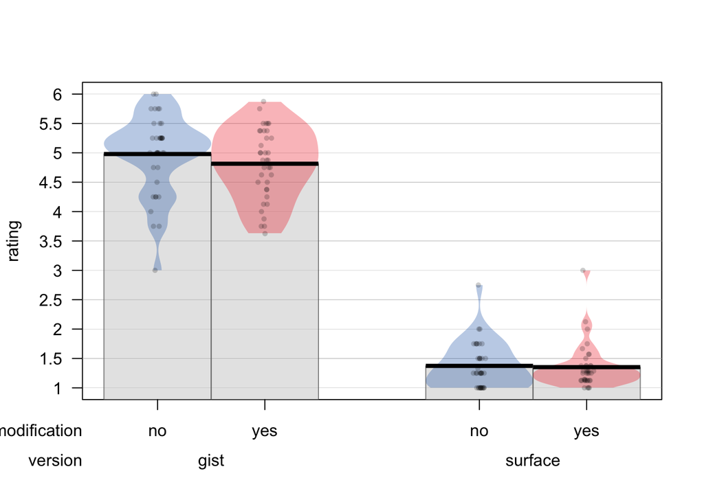

```r
library("yarrr")
pirateplot(rating ~ modification+version, data = df, theme = 1,
    inf.f.o = 0, # Turn off inf fill
    inf.b.o = 0, # Turn off inf border
    bean.b.o = 0,
    avg.line.fun = mean,
    bar.f.col = gray(.8), # bar filling color
    bar.b.col = gray(.4), # bar border color
    bar.f.o = .5, # bar filling opacity
    bar.b.o = .7 # bar border opacity
)
```

We conduct an analysis with four different methods: ART, PAR, RNK, and INT.

```r
library(ARTool)
library(effectsize)

# Implementation of the Inverse Normal Transform
int = function(x){
   qnorm((rank(x) - 0.5)/length(x))
}

# We use here the aov function to be consistent with the authors' analysis, also considering slope random effects
mr_art <- art(rating ~ 1 + modification*version + Error(participant_id/(1+modification*version)), data = df)
mr_par <- aov(rating ~ 1 + modification*version + Error(participant_id/(1+modification*version)), data = df)
mr_rnk <- aov(rank(rating) ~ 1 + modification*version + Error(participant_id/(1+modification*version)), data = df)
mr_int <- aov(int(rating) ~ 1 + modification*version + Error(participant_id/(1+modification*version)), data = df)
```

The results obtained with ART are as follows:

```r
# Function for printing the results for each method
printAnalysis <- function(num, method, model) {
  cat(num, ". Analysis using ", method, "\n\n", sep="")

  if(method == "ART") print(anova(model))
  else print(summary(model))

  print(eta_squared(model))
  print(cohens_f(model))
}

printAnalysis(1, "ART", mr_art)
```

```
## 1. Analysis using ART
##
## Analysis of Variance of Aligned Rank Transformed Data
##
## Table Type: Repeated Measures Analysis of Variance Table (Type I)
## Model: Repeated Measures (aov)
## Response: art(rating)
##
##                              Error Df Df.res F value   Pr(>F)
## 1 modification         prtcpnt_d:m  1     36   4.868 0.033825   *
## 2 version              prtcpnt_d:v  1     36 347.288  < 2e-16 ***
## 3 modification:version       pr_::  1     36   1.791 0.189200
## ---
## Signif. codes:   0 '***' 0.001 '**' 0.01 '*' 0.05 '.' 0.1 ' ' 1
## # Effect Size for ANOVA (Type I)
##
## Parameter | Eta2 (partial) |       95% CI
## -----------------------------------------
## 1         |           0.12 | [0.01, 1.00]
## 2         |           0.91 | [0.86, 1.00]
## 3         |           0.05 | [0.00, 1.00]
##
## - One-sided CIs: upper bound fixed at [1.00].# Effect Size for ANOVA (Type I)
##
## Parameter | Cohen's f (partial) |      95% CI
## ---------------------------------------------
## 1         |                0.37 | [0.07, Inf]
## 2         |                3.11 | [2.44, Inf]
## 3         |                0.22 | [0.00, Inf]
##
## - One-sided CIs: upper bound fixed at [Inf].
```

We observe that in addition to a clear strong effect of the `version` factor, ART shows a statistically significant effect ($p = .034$) effect of the `modification` factor, which leads the authors to conclude that *“modified videos that had already been presented during the fMRI session received lower story-change ratings than those that had been presented in the original version before”* [(Siestrup and Schubotz, 2023)](https://doi.org/10.1162/jocn_a_02047).

The results of the other methods, however, do not support this conclusion:

```r
printAnalysis(2, "PAR", mr_par)
```

```
## 2. Analysis using PAR
##
##
## Error: participant_id
##           Df Sum Sq Mean Sq F value Pr(>F)
## Residuals 36  19.89  0.5526
##
## Error: participant_id:modification
##              Df Sum Sq Mean Sq F value Pr(>F)
## modification  1  0.325  0.3249   2.702  0.109
## Residuals    36  4.330  0.1203
##
## Error: participant_id:version
##           Df Sum Sq Mean Sq F value Pr(>F)
## version    1  462.1   462.1    1377 <2e-16 ***
## Residuals 36   12.1     0.3
## ---
## Signif. codes:  0 '***' 0.001 '**' 0.01 '*' 0.05 '.' 0.1 ' ' 1
##
## Error: participant_id:modification:version
##                      Df Sum Sq Mean Sq F value Pr(>F)
## modification:version  1  0.191 0.19091   1.941  0.172
## Residuals            36  3.541 0.09836
## # Effect Size for ANOVA (Type I)
##
## Group                               |            Parameter | Eta2 (partial) |       95% CI
## ------------------------------------------------------------------------------------------
## participant_id:modification         |         modification |           0.07 | [0.00, 1.00]
## participant_id:version              |              version |           0.97 | [0.96, 1.00]
## participant_id:modification:version | modification:version |           0.05 | [0.00, 1.00]
##
## - One-sided CIs: upper bound fixed at [1.00].# Effect Size for ANOVA (Type I)
##
## Group                               |            Parameter | Cohen's f (partial) |      95% CI
## ----------------------------------------------------------------------------------------------
## participant_id:modification         |         modification |                0.27 | [0.00, Inf]
## participant_id:version              |              version |                6.19 | [4.94, Inf]
## participant_id:modification:version | modification:version |                0.23 | [0.00, Inf]
##
## - One-sided CIs: upper bound fixed at [Inf].
```

```r
printAnalysis(3, "RNK", mr_rnk)
```

```
## 3. Analysis using RNK
##
##
## Error: participant_id
##           Df Sum Sq Mean Sq F value Pr(>F)
## Residuals 36  27742   770.6
##
## Error: participant_id:modification
##              Df Sum Sq Mean Sq F value Pr(>F)
## modification  1    361   360.5   1.481  0.232
## Residuals    36   8767   243.5
##
## Error: participant_id:version
##           Df Sum Sq Mean Sq F value Pr(>F)
## version    1 202538  202538   346.2 <2e-16 ***
## Residuals 36  21061     585
## ---
## Signif. codes:  0 '***' 0.001 '**' 0.01 '*' 0.05 '.' 0.1 ' ' 1
##
## Error: participant_id:modification:version
##                      Df Sum Sq Mean Sq F value Pr(>F)
## modification:version  1    429   429.1   1.878  0.179
## Residuals            36   8223   228.4
## # Effect Size for ANOVA (Type I)
##
## Group                               |            Parameter | Eta2 (partial) |       95% CI
## ------------------------------------------------------------------------------------------
## participant_id:modification         |         modification |           0.04 | [0.00, 1.00]
## participant_id:version              |              version |           0.91 | [0.86, 1.00]
## participant_id:modification:version | modification:version |           0.05 | [0.00, 1.00]
##
## - One-sided CIs: upper bound fixed at [1.00].# Effect Size for ANOVA (Type I)
##
## Group                               |            Parameter | Cohen's f (partial) |      95% CI
## ----------------------------------------------------------------------------------------------
## participant_id:modification         |         modification |                0.20 | [0.00, Inf]
## participant_id:version              |              version |                3.10 | [2.43, Inf]
## participant_id:modification:version | modification:version |                0.23 | [0.00, Inf]
##
## - One-sided CIs: upper bound fixed at [Inf].
```

```r
printAnalysis(4, "INT", mr_int)
```

```
## 4. Analysis using INT
##
##
## Error: participant_id
##           Df Sum Sq Mean Sq F value Pr(>F)
## Residuals 36  18.65  0.5179
##
## Error: participant_id:modification
##              Df Sum Sq Mean Sq F value Pr(>F)
## modification  1  0.150  0.1499   0.734  0.397
## Residuals    36  7.354  0.2043
##
## Error: participant_id:version
##           Df Sum Sq Mean Sq F value Pr(>F)
## version    1  90.69   90.69   237.3 <2e-16 ***
## Residuals 36  13.76    0.38
## ---
## Signif. codes:  0 '***' 0.001 '**' 0.01 '*' 0.05 '.' 0.1 ' ' 1
##
## Error: participant_id:modification:version
##                      Df Sum Sq Mean Sq F value Pr(>F)
## modification:version  1  0.620  0.6203   3.828 0.0582 .
## Residuals            36  5.834  0.1621
## ---
## Signif. codes:  0 '***' 0.001 '**' 0.01 '*' 0.05 '.' 0.1 ' ' 1
## # Effect Size for ANOVA (Type I)
##
## Group                               |            Parameter | Eta2 (partial) |       95% CI
## ------------------------------------------------------------------------------------------
## participant_id:modification         |         modification |           0.02 | [0.00, 1.00]
## participant_id:version              |              version |           0.87 | [0.80, 1.00]
## participant_id:modification:version | modification:version |           0.10 | [0.00, 1.00]
##
## - One-sided CIs: upper bound fixed at [1.00].# Effect Size for ANOVA (Type I)
##
## Group                               |            Parameter | Cohen's f (partial) |      95% CI
## ----------------------------------------------------------------------------------------------
## participant_id:modification         |         modification |                0.14 | [0.00, Inf]
## participant_id:version              |              version |                2.57 | [1.99, Inf]
## participant_id:modification:version | modification:version |                0.33 | [0.00, Inf]
##
## - One-sided CIs: upper bound fixed at [Inf].
```

### Rate of false alarms

The authors also measured the rate of false alarms for modified videos, which can be thought off as a variable following a binomial distribution. For this dataset, the average probabilty of a false alarm was approximately 15%.

We start again by reading the data:

```r
alarm_rates <- read.csv("False_Alarm_Rate.csv", sep=",", header = TRUE)

df <- gather(alarm_rates, modversion, arate, no_surface:yes_gist, factor_key=TRUE)
df$modification <- ifelse(df$modversion %in% c('yes_surface', 'yes_gist'), 'yes', 'no')
df$version <- ifelse(df$modversion %in% c('yes_surface', 'no_surface'), 'surface', 'gist')
df <- df[c(1,4,5,3)]

df$participant_id <- factor(df$participant_id)
df$version <- factor(df$version)
df$modification <- factor(df$modification)
```

The authors used again ART for the analysis of the false alarm rate. Here, we compare the results of ART with the results of the three other methods.

```r
# We use here the aov function to be consistent with the authors' analysis, also considering slope random effects
ma_art <- art(arate ~ 1 + modification*version + Error(participant_id/(1+modification*version)), data = df)
ma_par <- aov(arate ~ 1 + modification*version + Error(participant_id/(1+modification*version)), data = df)
ma_rnk <- aov(rank(arate) ~ 1 + modification*version + Error(participant_id/(1+modification*version)), data = df)
ma_int <- aov(int(arate) ~ 1 + modification*version + Error(participant_id/(1+modification*version)), data = df)

printAnalysis(1, "ART", ma_art)
```

```
## 1. Analysis using ART
##
## Analysis of Variance of Aligned Rank Transformed Data
##
## Table Type: Repeated Measures Analysis of Variance Table (Type I)
## Model: Repeated Measures (aov)
## Response: art(arate)
##
##                              Error Df Df.res F value     Pr(>F)
## 1 modification         prtcpnt_d:m  1     36  41.592 1.7519e-07 ***
## 2 version              prtcpnt_d:v  1     36 473.629 < 2.22e-16 ***
## 3 modification:version       pr_::  1     36  18.155 0.00013988 ***
## ---
## Signif. codes:   0 '***' 0.001 '**' 0.01 '*' 0.05 '.' 0.1 ' ' 1
## # Effect Size for ANOVA (Type I)
##
## Parameter | Eta2 (partial) |       95% CI
## -----------------------------------------
## 1         |           0.54 | [0.34, 1.00]
## 2         |           0.93 | [0.89, 1.00]
## 3         |           0.34 | [0.14, 1.00]
##
## - One-sided CIs: upper bound fixed at [1.00].# Effect Size for ANOVA (Type I)
##
## Parameter | Cohen's f (partial) |      95% CI
## ---------------------------------------------
## 1         |                1.07 | [0.73, Inf]
## 2         |                3.63 | [2.86, Inf]
## 3         |                0.71 | [0.40, Inf]
##
## - One-sided CIs: upper bound fixed at [Inf].
```

```r
printAnalysis(2, "PAR", ma_par)
```

```
## 2. Analysis using PAR
##
##
## Error: participant_id
##           Df Sum Sq Mean Sq F value Pr(>F)
## Residuals 36  1.233 0.03424
##
## Error: participant_id:modification
##              Df Sum Sq Mean Sq F value   Pr(>F)
## modification  1 0.1775 0.17747   15.21 0.000404 ***
## Residuals    36 0.4202 0.01167
## ---
## Signif. codes:  0 '***' 0.001 '**' 0.01 '*' 0.05 '.' 0.1 ' ' 1
##
## Error: participant_id:version
##           Df Sum Sq Mean Sq F value  Pr(>F)
## version    1 2.8050  2.8050     110 1.7e-12 ***
## Residuals 36 0.9177  0.0255
## ---
## Signif. codes:  0 '***' 0.001 '**' 0.01 '*' 0.05 '.' 0.1 ' ' 1
##
## Error: participant_id:modification:version
##                      Df Sum Sq Mean Sq F value Pr(>F)
## modification:version  1 0.1015 0.10146   6.191 0.0176 *
## Residuals            36 0.5899 0.01639
## ---
## Signif. codes:  0 '***' 0.001 '**' 0.01 '*' 0.05 '.' 0.1 ' ' 1
## # Effect Size for ANOVA (Type I)
##
## Group                               |            Parameter | Eta2 (partial) |       95% CI
## ------------------------------------------------------------------------------------------
## participant_id:modification         |         modification |           0.30 | [0.11, 1.00]
## participant_id:version              |              version |           0.75 | [0.63, 1.00]
## participant_id:modification:version | modification:version |           0.15 | [0.02, 1.00]
##
## - One-sided CIs: upper bound fixed at [1.00].# Effect Size for ANOVA (Type I)
##
## Group                               |            Parameter | Cohen's f (partial) |      95% CI
## ----------------------------------------------------------------------------------------------
## participant_id:modification         |         modification |                0.65 | [0.34, Inf]
## participant_id:version              |              version |                1.75 | [1.31, Inf]
## participant_id:modification:version | modification:version |                0.41 | [0.12, Inf]
##
## - One-sided CIs: upper bound fixed at [Inf].
```

```r
printAnalysis(3, "RNK", ma_rnk)
```

```
## 3. Analysis using RNK
##
##
## Error: participant_id
##           Df Sum Sq Mean Sq F value Pr(>F)
## Residuals 36  31152   865.3
##
## Error: participant_id:modification
##              Df Sum Sq Mean Sq F value   Pr(>F)
## modification  1   9876    9876   26.83 8.66e-06 ***
## Residuals    36  13251     368
## ---
## Signif. codes:  0 '***' 0.001 '**' 0.01 '*' 0.05 '.' 0.1 ' ' 1
##
## Error: participant_id:version
##           Df Sum Sq Mean Sq F value   Pr(>F)
## version    1 116537  116537   198.1 3.31e-16 ***
## Residuals 36  21180     588
## ---
## Signif. codes:  0 '***' 0.001 '**' 0.01 '*' 0.05 '.' 0.1 ' ' 1
##
## Error: participant_id:modification:version
##                      Df Sum Sq Mean Sq F value Pr(>F)
## modification:version  1   4368    4368   6.388  0.016 *
## Residuals            36  24613     684
## ---
## Signif. codes:  0 '***' 0.001 '**' 0.01 '*' 0.05 '.' 0.1 ' ' 1
## # Effect Size for ANOVA (Type I)
##
## Group                               |            Parameter | Eta2 (partial) |       95% CI
## ------------------------------------------------------------------------------------------
## participant_id:modification         |         modification |           0.43 | [0.22, 1.00]
## participant_id:version              |              version |           0.85 | [0.77, 1.00]
## participant_id:modification:version | modification:version |           0.15 | [0.02, 1.00]
##
## - One-sided CIs: upper bound fixed at [1.00].# Effect Size for ANOVA (Type I)
##
## Group                               |            Parameter | Cohen's f (partial) |      95% CI
## ----------------------------------------------------------------------------------------------
## participant_id:modification         |         modification |                0.86 | [0.54, Inf]
## participant_id:version              |              version |                2.35 | [1.81, Inf]
## participant_id:modification:version | modification:version |                0.42 | [0.13, Inf]
##
## - One-sided CIs: upper bound fixed at [Inf].
```

```r
printAnalysis(4, "INT", ma_int)
```

```
## 4. Analysis using INT
##
##
## Error: participant_id
##           Df Sum Sq Mean Sq F value Pr(>F)
## Residuals 36  17.81  0.4946
##
## Error: participant_id:modification
##              Df Sum Sq Mean Sq F value   Pr(>F)
## modification  1  3.818   3.818   22.67 3.11e-05 ***
## Residuals    36  6.062   0.168
## ---
## Signif. codes:  0 '***' 0.001 '**' 0.01 '*' 0.05 '.' 0.1 ' ' 1
##
## Error: participant_id:version
##           Df Sum Sq Mean Sq F value   Pr(>F)
## version    1  47.45   47.45   141.7 4.84e-14 ***
## Residuals 36  12.05    0.33
## ---
## Signif. codes:  0 '***' 0.001 '**' 0.01 '*' 0.05 '.' 0.1 ' ' 1
##
## Error: participant_id:modification:version
##                      Df Sum Sq Mean Sq F value Pr(>F)
## modification:version  1  1.861  1.8611   7.354 0.0102 *
## Residuals            36  9.111  0.2531
## ---
## Signif. codes:  0 '***' 0.001 '**' 0.01 '*' 0.05 '.' 0.1 ' ' 1
## # Effect Size for ANOVA (Type I)
##
## Group                               |            Parameter | Eta2 (partial) |       95% CI
## ------------------------------------------------------------------------------------------
## participant_id:modification         |         modification |           0.39 | [0.18, 1.00]
## participant_id:version              |              version |           0.80 | [0.69, 1.00]
## participant_id:modification:version | modification:version |           0.17 | [0.03, 1.00]
##
## - One-sided CIs: upper bound fixed at [1.00].# Effect Size for ANOVA (Type I)
##
## Group                               |            Parameter | Cohen's f (partial) |      95% CI
## ----------------------------------------------------------------------------------------------
## participant_id:modification         |         modification |                0.79 | [0.47, Inf]
## participant_id:version              |              version |                1.98 | [1.50, Inf]
## participant_id:modification:version | modification:version |                0.45 | [0.16, Inf]
##
## - One-sided CIs: upper bound fixed at [Inf].
```

We notice that all methods show statistically significant effects for both factors as well as we their interaction. However, ART results in small $p$-values and finds larger effect sizes.

The following figure summarizes the results.

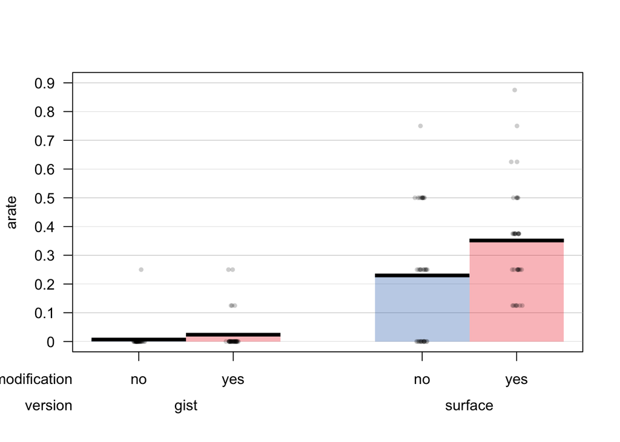

```r
pirateplot(arate ~ modification+version, data = df, theme = 2,
     inf.f.o = 0, # Turn off inf fill
     inf.b.o = 0, # Turn off inf border
     point.o = .2,   # Turn up points
     bar.f.o = .3, # Turn up bars
     bean.f.o = 0, # Light bean filling
     bean.b.o = 0, # Light bean border
     avg.line.o = 1, # Turn off average line
     point.col = "black"
)
```

As we discuss in the paper, statistically significant interactions in the presence of strong main effects may not be trusted. Although the difference between the *yes* and *no* modification conditions is clearly larger for surface modifications, this trend does not necessarily imply an intrinsic interaction effect. We observe that the interaction does not cross over, and the fact that the difference is smaller for gist modifications can be simply attributed to the fact that the measure is bounded by zero.

### AUC measure

Another measure of memory performance that the authors studied using ART is the *Area Under the ROC Curve*, or AUC, which takes values between 0 and 1. We first read and plot the data:

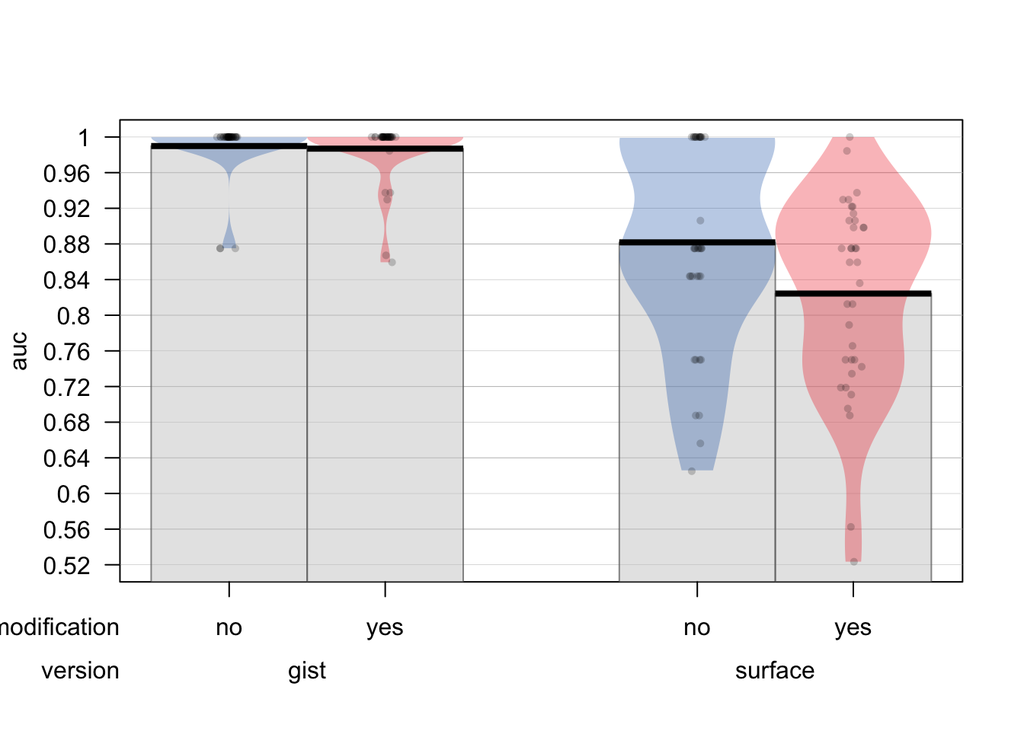

```r
auc_data <- read.csv("AUC.csv", sep=",", header = TRUE)
df <- gather(auc_data, modversion, auc, no_surface:yes_gist, factor_key=TRUE)
df$modification <- ifelse(df$modversion %in% c('yes_surface', 'yes_gist'), 'yes', 'no')
df$version <- ifelse(df$modversion %in% c('yes_surface', 'no_surface'), 'surface', 'gist')
df <- df[c(1,4,5,3)]

df$participant_id <- factor(df$participant_id)
df$version <- factor(df$version)
df$modification <- factor(df$modification)

pirateplot(auc ~ modification+version, data = df, theme = 1,
    inf.f.o = 0, # Turn off inf fill
    inf.b.o = 0, # Turn off inf border
    bean.b.o = 0,
    avg.line.fun = mean,
    bar.f.col = gray(.8), # bar filling color
    bar.b.col = gray(.4), # bar border color
    bar.f.o = .5, # bar filling opacity
    bar.b.o = .7 # bar border opacity
)
```

We then present our analysis with the four different methods. We observe again that altough all methods lead to the same conclusions, ART finds larger effect sizes. Discrepencies are more pronounced for the interaction effect, which should again be interpreted with caution.

```r
# We use here the aov function to be consistent with the authors' analysis, also considering slope random effects
mauc_art <- art(auc ~ 1 + modification*version + Error(participant_id/(1+modification*version)), data = df)
mauc_par <- aov(auc ~ 1 + modification*version + Error(participant_id/(1+modification*version)), data = df)
mauc_rnk <- aov(rank(auc) ~ 1 + modification*version + Error(participant_id/(1+modification*version)), data = df)
mauc_int <- aov(int(auc) ~ 1 + modification*version + Error(participant_id/(1+modification*version)), data = df)

printAnalysis(1, "ART", mauc_art)
```

```
## 1. Analysis using ART
##
## Analysis of Variance of Aligned Rank Transformed Data
##
## Table Type: Repeated Measures Analysis of Variance Table (Type I)
## Model: Repeated Measures (aov)
## Response: art(auc)
##
##                              Error Df Df.res F value     Pr(>F)
## 1 modification         prtcpnt_d:m  1     36  18.941 0.00010657 ***
## 2 version              prtcpnt_d:v  1     36 239.974 < 2.22e-16 ***
## 3 modification:version       pr_::  1     36  12.353 0.00120860  **
## ---
## Signif. codes:   0 '***' 0.001 '**' 0.01 '*' 0.05 '.' 0.1 ' ' 1
## # Effect Size for ANOVA (Type I)
##
## Parameter | Eta2 (partial) |       95% CI
## -----------------------------------------
## 1         |           0.34 | [0.15, 1.00]
## 2         |           0.87 | [0.80, 1.00]
## 3         |           0.26 | [0.08, 1.00]
##
## - One-sided CIs: upper bound fixed at [1.00].# Effect Size for ANOVA (Type I)
##
## Parameter | Cohen's f (partial) |      95% CI
## ---------------------------------------------
## 1         |                0.73 | [0.41, Inf]
## 2         |                2.58 | [2.00, Inf]
## 3         |                0.59 | [0.29, Inf]
##
## - One-sided CIs: upper bound fixed at [Inf].
```

```r
printAnalysis(2, "PAR", mauc_par)
```

```
## 2. Analysis using PAR
##
##
## Error: participant_id
##           Df Sum Sq Mean Sq F value Pr(>F)
## Residuals 36 0.3973 0.01104
##
## Error: participant_id:modification
##              Df  Sum Sq Mean Sq F value  Pr(>F)
## modification  1 0.03374 0.03374   9.813 0.00343 **
## Residuals    36 0.12376 0.00344
## ---
## Signif. codes:  0 '***' 0.001 '**' 0.01 '*' 0.05 '.' 0.1 ' ' 1
##
## Error: participant_id:version
##           Df Sum Sq Mean Sq F value  Pr(>F)
## version    1 0.6778  0.6778   79.07 1.3e-10 ***
## Residuals 36 0.3086  0.0086
## ---
## Signif. codes:  0 '***' 0.001 '**' 0.01 '*' 0.05 '.' 0.1 ' ' 1
##
## Error: participant_id:modification:version
##                      Df  Sum Sq Mean Sq F value Pr(>F)
## modification:version  1 0.02746 0.02746     6.4 0.0159 *
## Residuals            36 0.15445 0.00429
## ---
## Signif. codes:  0 '***' 0.001 '**' 0.01 '*' 0.05 '.' 0.1 ' ' 1
## # Effect Size for ANOVA (Type I)
##
## Group                               |            Parameter | Eta2 (partial) |       95% CI
## ------------------------------------------------------------------------------------------
## participant_id:modification         |         modification |           0.21 | [0.05, 1.00]
## participant_id:version              |              version |           0.69 | [0.54, 1.00]
## participant_id:modification:version | modification:version |           0.15 | [0.02, 1.00]
##
## - One-sided CIs: upper bound fixed at [1.00].# Effect Size for ANOVA (Type I)
##
## Group                               |            Parameter | Cohen's f (partial) |      95% CI
## ----------------------------------------------------------------------------------------------
## participant_id:modification         |         modification |                0.52 | [0.23, Inf]
## participant_id:version              |              version |                1.48 | [1.08, Inf]
## participant_id:modification:version | modification:version |                0.42 | [0.13, Inf]
##
## - One-sided CIs: upper bound fixed at [Inf].
```

```r
printAnalysis(3, "RNK", mauc_rnk)
```

```
## 3. Analysis using RNK
##
##
## Error: participant_id
##           Df Sum Sq Mean Sq F value Pr(>F)
## Residuals 36  37896    1053
##
## Error: participant_id:modification
##              Df Sum Sq Mean Sq F value   Pr(>F)
## modification  1   6423    6423   13.97 0.000644 ***
## Residuals    36  16556     460
## ---
## Signif. codes:  0 '***' 0.001 '**' 0.01 '*' 0.05 '.' 0.1 ' ' 1
##
## Error: participant_id:version
##           Df Sum Sq Mean Sq F value   Pr(>F)
## version    1 107838  107838   136.5 8.32e-14 ***
## Residuals 36  28441     790
## ---
## Signif. codes:  0 '***' 0.001 '**' 0.01 '*' 0.05 '.' 0.1 ' ' 1
##
## Error: participant_id:modification:version
##                      Df Sum Sq Mean Sq F value Pr(>F)
## modification:version  1   3483    3483   4.743 0.0361 *
## Residuals            36  26440     734
## ---
## Signif. codes:  0 '***' 0.001 '**' 0.01 '*' 0.05 '.' 0.1 ' ' 1
## # Effect Size for ANOVA (Type I)
##
## Group                               |            Parameter | Eta2 (partial) |       95% CI
## ------------------------------------------------------------------------------------------
## participant_id:modification         |         modification |           0.28 | [0.09, 1.00]
## participant_id:version              |              version |           0.79 | [0.68, 1.00]
## participant_id:modification:version | modification:version |           0.12 | [0.00, 1.00]
##
## - One-sided CIs: upper bound fixed at [1.00].# Effect Size for ANOVA (Type I)
##
## Group                               |            Parameter | Cohen's f (partial) |      95% CI
## ----------------------------------------------------------------------------------------------
## participant_id:modification         |         modification |                0.62 | [0.32, Inf]
## participant_id:version              |              version |                1.95 | [1.47, Inf]
## participant_id:modification:version | modification:version |                0.36 | [0.07, Inf]
##
## - One-sided CIs: upper bound fixed at [Inf].
```

```r
printAnalysis(4, "INT", mauc_int)
```

```
## 4. Analysis using INT
##
##
## Error: participant_id
##           Df Sum Sq Mean Sq F value Pr(>F)
## Residuals 36  20.67  0.5741
##
## Error: participant_id:modification
##              Df Sum Sq Mean Sq F value   Pr(>F)
## modification  1  2.677  2.6768   14.45 0.000536 ***
## Residuals    36  6.668  0.1852
## ---
## Signif. codes:  0 '***' 0.001 '**' 0.01 '*' 0.05 '.' 0.1 ' ' 1
##
## Error: participant_id:version
##           Df Sum Sq Mean Sq F value   Pr(>F)
## version    1  44.92   44.92   105.2 3.14e-12 ***
## Residuals 36  15.37    0.43
## ---
## Signif. codes:  0 '***' 0.001 '**' 0.01 '*' 0.05 '.' 0.1 ' ' 1
##
## Error: participant_id:modification:version
##                      Df Sum Sq Mean Sq F value Pr(>F)
## modification:version  1  1.567  1.5667    5.39  0.026 *
## Residuals            36 10.465  0.2907
## ---
## Signif. codes:  0 '***' 0.001 '**' 0.01 '*' 0.05 '.' 0.1 ' ' 1
## # Effect Size for ANOVA (Type I)
##
## Group                               |            Parameter | Eta2 (partial) |       95% CI
## ------------------------------------------------------------------------------------------
## participant_id:modification         |         modification |           0.29 | [0.10, 1.00]
## participant_id:version              |              version |           0.75 | [0.62, 1.00]
## participant_id:modification:version | modification:version |           0.13 | [0.01, 1.00]
##
## - One-sided CIs: upper bound fixed at [1.00].# Effect Size for ANOVA (Type I)
##
## Group                               |            Parameter | Cohen's f (partial) |      95% CI
## ----------------------------------------------------------------------------------------------
## participant_id:modification         |         modification |                0.63 | [0.33, Inf]
## participant_id:version              |              version |                1.71 | [1.27, Inf]
## participant_id:modification:version | modification:version |                0.39 | [0.10, Inf]
##
## - One-sided CIs: upper bound fixed at [Inf].
```